# Glioblastoma_scRNAseq_CNV

- Show All Code
- Hide All Code
- View Source

Authors

Azzeddine ALILICHE

Anais HLUSZKO

Corentin OSTA

Published

November 4, 2026

```r
the.seed <- 42
set.seed(the.seed)
suppressPackageStartupMessages({
  library(Seurat)
  library(dplyr)
  library(ggplot2)
  library(infercnv)
})
```

```r
sample.name <- "brain_DV200"
```

**Why inferCNV ?**

GBmap only tells us that some cells *look like* tumour cells. To confirm which cells are malignant, we look at DNA copy number alterations : when a part of a chromosome is gained or lost, all its genes are a bit more or less expressed. Glioblastoma cells almost always have a **gain of chromosome 7 and a loss of chromosome 10**, normal cells don’t.

inferCNV compares the expression along each chromosome to a group of cells that we know are normal (the reference).

Installation (run once) : on Windows, install JAGS first (https://sourceforge.net/projects/mcmc-jags/), then :

```r
install.packages("rjags")
BiocManager::install("infercnv")
```

we reload the annotated object

```r
load(paste0('../data/processed_data/', sample.name, '_ANNOTATED.rda'))
table(sobjFiltrd$celltype)
```

```
Excitatory neurons    Tumour MES-like            Myeloid    Tumour NPC-like
               813                805                673                515
  Oligodendrocytes           Vascular            Unclear Inhibitory neurons
               511                177                176                136
               OPC         Astrocytes         T/NK cells
                93                 57                 49
```

**Reference cells** : cell types that can’t be tumour cells in a glioblastoma (immune, vascular) and oligodendrocytes. All the other cells are tested, including neurons as a sanity check (they should come out normal).

```r
ref_groups <- c("Oligodendrocytes", "Myeloid", "T/NK cells", "Vascular")

annotations <- data.frame(
  row.names = colnames(sobjFiltrd),
  celltype = as.character(sobjFiltrd$celltype))
```

Gene positions on the chromosomes (hg38, from the Trinity CTAT / inferCNV resources) : https://data.broadinstitute.org/Trinity/CTAT/cnv/hg38_gencode_v27.txt

```r
gene_order <- "../data/reference/hg38_gencode_v27.txt"

infercnv_obj <- CreateInfercnvObject(
  raw_counts_matrix = GetAssayData(sobjFiltrd, layer = "counts"),
  annotations_file = annotations,
  delim = "\t",
  gene_order_file = gene_order,
  ref_group_names = ref_groups,
  chr_exclude = c("chrM", "chrY"))
```

Now we run inferCNV, cutoff = 0.1 is the recommended value for 10x data. We don’t use the HMM (CNV calling per region), we only need the smoothed expression to score each cell. `save_rds = FALSE` avoids saving an object at each step (~2.5 GB), only the final object is kept.

```r
infercnv_obj <- infercnv::run(
  infercnv_obj,
  cutoff = 0.1,
  out_dir = "../data/infercnv_out",
  cluster_by_groups = TRUE,
  denoise = TRUE,
  HMM = FALSE,
  save_rds = FALSE,
  num_threads = 4)
```

The heatmap is saved in `../data/infercnv_out/infercnv.png` : the reference cells are on top, the tested cells below. Tumour cells should show a red band on chr7 (gain) and a blue band on chr10 (loss).

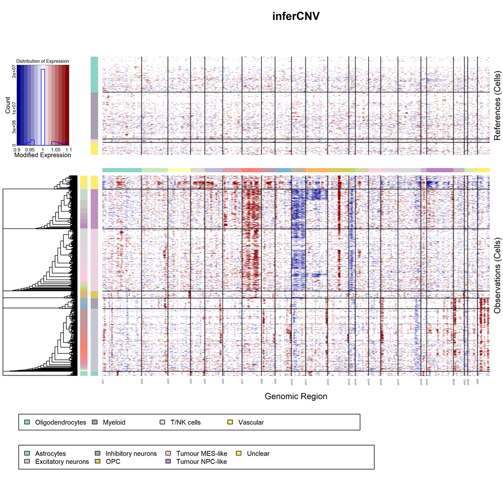

```r
knitr::include_graphics("../data/infercnv_out/infercnv.png")
```

**Observations on the heatmap**

- The reference cells (top) are flat, as expected : no region is consistently red or blue.
- **Tumour NPC-like and Tumour MES-like cells show the classic glioblastoma signature** : a gain of chr7 (red) and a loss of chr10 (blue), present in most of the cells.
- Other alterations are shared by the tumour cells : a short and strong gain on **chr12** and a loss of **chr13**. A loss on **chr11** is only seen in a part of the NPC-like cells, which could be a subclone.
- The neurons are not flat (red on chrX, chr16, chr20), but chr7 and chr10 are normal. This is most likely an artefact : neurons are not in the reference, so groups of neuron-specific genes located close to each other on a chromosome look like CNVs.

**CNV score per cell**

The smoothed expression is centered around 1, so we score each cell :

- `cnv_score` : mean squared deviation from 1, high when the cell has many alterations
- `chr7` and `chr10` : mean value on these chromosomes, > 1 is a gain and < 1 a loss

```r
expr <- infercnv_obj@expr.data
chr <- infercnv_obj@gene_order[rownames(expr), "chr"]

cnv <- data.frame(
  row.names = colnames(expr),
  cnv_score = colMeans((expr - 1)^2),
  chr7 = colMeans(expr[chr == "chr7", ]),
  chr10 = colMeans(expr[chr == "chr10", ]))
cnv$chr7_minus_chr10 <- cnv$chr7 - cnv$chr10

sobjFiltrd <- AddMetaData(sobjFiltrd, cnv)
```

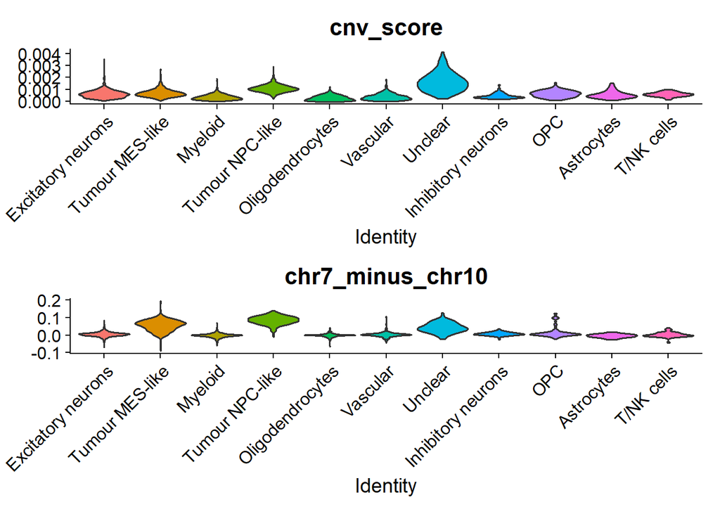

```r
VlnPlot(sobjFiltrd, features = c("cnv_score", "chr7_minus_chr10"),
        group.by = "celltype", pt.size = 0, ncol = 1) & RotatedAxis()
```

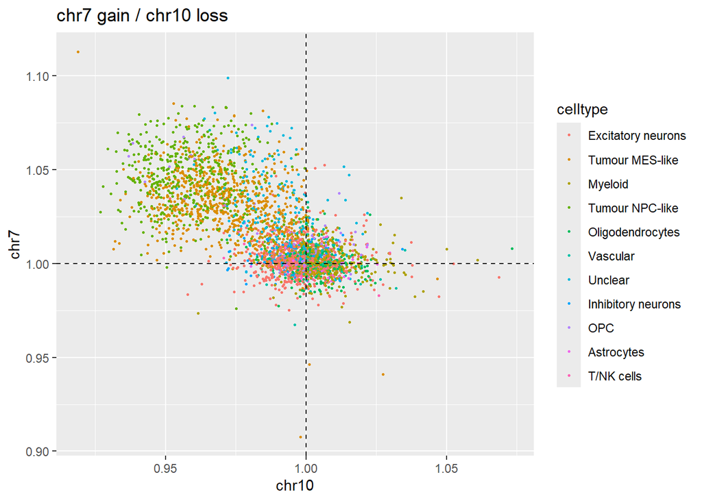

```r
ggplot(sobjFiltrd@meta.data, aes(x = chr10, y = chr7, colour = celltype)) +
  geom_point(size = 0.5) +
  geom_hline(yintercept = 1, linetype = "dashed") +
  geom_vline(xintercept = 1, linetype = "dashed") +
  ggtitle("chr7 gain / chr10 loss")
```

**Classification**

A cell is called malignant when its chr7 - chr10 difference is above what we see in 99% of the reference cells. This threshold is a choice, check it on the plots above.

```r
is_ref <- sobjFiltrd$celltype %in% ref_groups
threshold <- quantile(sobjFiltrd$chr7_minus_chr10[is_ref], 0.99)

sobjFiltrd$cnv_status <- ifelse(sobjFiltrd$chr7_minus_chr10 > threshold, "Malignant", "Normal")

table(sobjFiltrd$celltype, sobjFiltrd$cnv_status)
```

```
                     Malignant Normal
  Excitatory neurons        18    795
  Tumour MES-like          612    193
  Myeloid                    5    668
  Tumour NPC-like          497     18
  Oligodendrocytes           3    508
  Vascular                   4    173
  Unclear                  109     67
  Inhibitory neurons         2    134
  OPC                       15     78
  Astrocytes                 0     57
  T/NK cells                 3     46
```

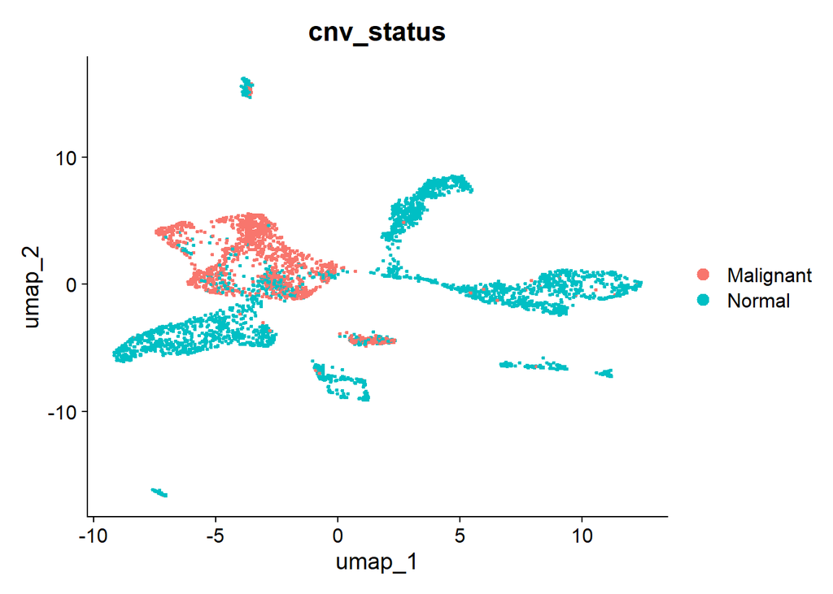

```r
DimPlot(sobjFiltrd, group.by = "cnv_status")
```

**Results per cell type**

```r
cnv_summary <- sobjFiltrd@meta.data %>%
  mutate(group = ifelse(celltype %in% ref_groups, "Reference", "Tested")) %>%
  group_by(group, celltype) %>%
  summarise(n = n(),
            pct_malignant = round(100 * mean(cnv_status == "Malignant")),
            median_chr7 = round(median(chr7), 3),
            median_chr10 = round(median(chr10), 3),
            .groups = "drop") %>%
  arrange(desc(group), desc(pct_malignant))

knitr::kable(cnv_summary, col.names = c("Group", "Cell type", "n", "% malignant", "Median chr7", "Median chr10"))
```

| Group | Cell type | n | % malignant | Median chr7 | Median chr10 |
| --- | --- | --- | --- | --- | --- |
| Tested | Tumour NPC-like | 515 | 97 | 1.045 | 0.959 |
| Tested | Tumour MES-like | 805 | 76 | 1.030 | 0.974 |
| Tested | Unclear | 176 | 62 | 1.028 | 0.989 |
| Tested | OPC | 93 | 16 | 1.006 | 0.998 |
| Tested | Excitatory neurons | 813 | 2 | 1.001 | 0.997 |
| Tested | Inhibitory neurons | 136 | 1 | 1.003 | 0.997 |
| Tested | Astrocytes | 57 | 0 | 0.999 | 1.001 |
| Reference | T/NK cells | 49 | 6 | 1.003 | 1.001 |
| Reference | Vascular | 177 | 2 | 1.001 | 1.001 |
| Reference | Myeloid | 673 | 1 | 1.001 | 1.002 |
| Reference | Oligodendrocytes | 511 | 1 | 1.001 | 1.001 |

**Interpretation**

- **Tumour NPC-like (97% malignant) and Tumour MES-like (76%)** : the GBmap annotation is confirmed, these clusters are tumour cells.
- **About 24% of the MES-like cluster is called normal** : these can be reactive astrocytes (they look like MES-like cells but have no CNV) or tumour cells with a weaker signal close to the threshold. For the next steps we use `cnv_status` rather than the cluster label to select tumour cells.
- **Unclear (62% malignant)** : this cluster is mostly made of tumour cells of lower quality (low UMI counts), not debris. Keeping it was the right choice.
- **OPC (16% malignant)** : mostly normal OPC, not OPC-like tumour cells.
- **Neurons and astrocytes (0 to 2%)** : normal, the sanity check works.
- **Reference cells (1 to 6%)** : this is the expected false positive rate with a threshold at the 99th percentile of the reference. T/NK cells are a bit higher (6%) but there are only 49 cells.

**Which gene is behind the chr12 gain ?**

The chr12 band could match the CDK4 / MDM2 region (12q14-15), a known amplification in glioblastoma. We check the expression of these genes.

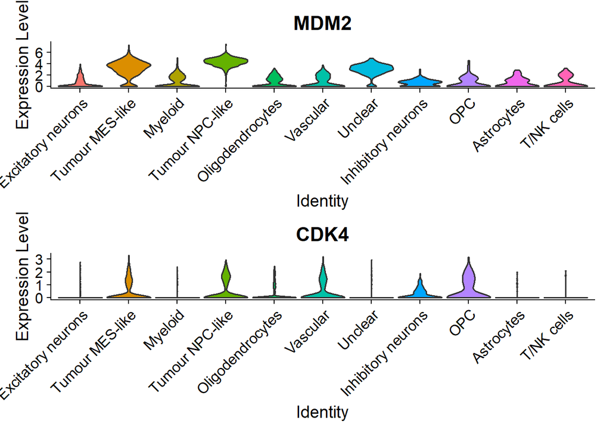

```r
VlnPlot(sobjFiltrd, features = c("MDM2", "CDK4"), group.by = "celltype", pt.size = 0, ncol = 1) & RotatedAxis()
```

**Limits**

- The classification depends on the threshold (99th percentile of the reference), which is a choice.
- inferCNV detects large alterations (whole chromosome or arm), not mutations or small events.
- The reference only contains cell types present in our sample, neurons are not in it which creates artefacts in the neuron cells.

```r
save(sobjFiltrd, file = paste0('../data/processed_data/', sample.name, '_CNV.rda'))
```